# Leitura e Armazenamento dos dados

Daniel Maurenza de Oliveira

https://github.com/dmaurenza/Curso-Intermediario-R

Nesta aula vamos aprender como importar dados externos, fazer algumas manipulações e exportar (armazenar) os resultados. Também vamos ver algumas funções úteis para serem utilizadas durante as análises

# Elementos da Aula

1. Leitura dos dados
2. Funções úteis
3. Exportando dados

## Leitura dos dados

Nosso principal uso da linguagem de programação R é a manipulação e análise de dados. Para tanto, utilizamos dados. Existem duas formas armazenar os dados. A primeira é gerarmos os dados dentro do R, conforme fizemos nas aulas anteriores. A segunda forma, e mais comumente utilizada, é importarmos dados externos

De modo geral, os dados são armazenados em 3 formas diferentes:

- arquivos de Excel com extensão: .xlsx e .xls;
- arquivos separados por vírgulas: .csv;
- arquivos de texto separado por tabulação: .txt (menos utilizado);

Vamos importar os dados da planilha alunos. Mas antes, vamos “limpar” o ambiente que estamos trabalhando. Assim, não teremos nenhum objeto da aula anterior.

Vamos iniciar com o arquivo csv. É possivel utilizar a função “read” de diversos pacotes

```r
# Usando pacote "utils"
alunos_csv <- read.csv(file = "dados/alunos.csv")
alunos_csv
```

```
##                          nome idade      sexo altura peso transporte semestre
## 1 Daniel Maurenza de Oliveira    39 Masculino   1.70   72    Publico        5
## 2                       Maria    20         F   1.58   49    Publico        4
## 3                        Joao    40         M   1.80   90    Privado        5
## 4                       Joana    25         F   1.75   65    Publico        1
##   pe mao iniciante
## 1 40  22      TRUE
## 2 35  20     FALSE
## 3 37  20     FALSE
## 4 33  21      TRUE
```

```r
alunos_csv <- read.csv(file = "dados/alunos.csv", header = F)
alunos_csv
```

```
##                            V1    V2        V3     V4   V5         V6       V7
## 1                        nome idade      sexo altura peso transporte semestre
## 2 Daniel Maurenza de Oliveira    39 Masculino   1.70   72    Publico        5
## 3                       Maria    20         F   1.58   49    Publico        4
## 4                        Joao    40         M    1.8   90    Privado        5
## 5                       Joana    25         F   1.75   65    Publico        1
##   V8  V9       V10
## 1 pe mao iniciante
## 2 40  22      TRUE
## 3 35  20     FALSE
## 4 37  20     FALSE
## 5 33  21      TRUE
```

```r
alunos_csv <- read.csv(file = "dados/alunos.csv", header = T)
alunos_csv
```

```
##                          nome idade      sexo altura peso transporte semestre
## 1 Daniel Maurenza de Oliveira    39 Masculino   1.70   72    Publico        5
## 2                       Maria    20         F   1.58   49    Publico        4
## 3                        Joao    40         M   1.80   90    Privado        5
## 4                       Joana    25         F   1.75   65    Publico        1
##   pe mao iniciante
## 1 40  22      TRUE
## 2 35  20     FALSE
## 3 37  20     FALSE
## 4 33  21      TRUE
```

Dependendo da configuração do seu computador, você deve usar a função alternativa

```r
alunos_csv2 <- read.csv2(file = "dados/alunos.csv")
alunos_csv2
```

```
##        nome.idade.sexo.altura.peso.transporte.semestre.pe.mao.iniciante
## 1 Daniel Maurenza de Oliveira,39,Masculino,1.70,72,Publico,5,40,22,TRUE
## 2                              Maria,20,F,1.58,49,Publico,4,35,20,FALSE
## 3                                Joao,40,M,1.8,90,Privado,5,37,20,FALSE
## 4                               Joana,25,F,1.75,65,Publico,1,33,21,TRUE
```

```r
alunos_csv2 <- read.csv2(file = "dados/alunos.csv", header = TRUE, sep = ",")
alunos_csv2
```

```
##                          nome idade      sexo altura peso transporte semestre
## 1 Daniel Maurenza de Oliveira    39 Masculino   1.70   72    Publico        5
## 2                       Maria    20         F   1.58   49    Publico        4
## 3                        Joao    40         M    1.8   90    Privado        5
## 4                       Joana    25         F   1.75   65    Publico        1
##   pe mao iniciante
## 1 40  22      TRUE
## 2 35  20     FALSE
## 3 37  20     FALSE
## 4 33  21      TRUE
```

Arquivos .csv também podem ser importados através do pacote “tidyverse”.

```r
#install.packages("tidyverse", dependencies = T)
library(tidyverse)
alunos_csv <- read_csv(file = "dados/alunos.csv", col_names = F)
alunos_csv
```

```
## # A tibble: 5 × 10
##   X1                       X2    X3    X4    X5    X6    X7    X8    X9    X10
##   <chr>                    <chr> <chr> <chr> <chr> <chr> <chr> <chr> <chr> <chr>
## 1 nome                     idade sexo  altu… peso  tran… seme… pe    mao   inic…
## 2 Daniel Maurenza de Oliv… 39    Masc… 1.70  72    Publ… 5     40    22    TRUE
## 3 Maria                    20    F     1.58  49    Publ… 4     35    20    FALSE
## 4 Joao                     40    M     1.8   90    Priv… 5     37    20    FALSE
## 5 Joana                    25    F     1.75  65    Publ… 1     33    21    TRUE
```

```r
alunos_csv <- read_csv(file = "dados/alunos.csv", col_names = T)
alunos_csv
```

```
## # A tibble: 4 × 10
##   nome              idade sexo  altura  peso trans…¹ semes…²    pe   mao inici…³
##   <chr>             <dbl> <chr>  <dbl> <dbl> <chr>     <dbl> <dbl> <dbl> <lgl>
## 1 Daniel Maurenza …    39 Masc…   1.7     72 Publico       5    40    22 TRUE
## 2 Maria                20 F       1.58    49 Publico       4    35    20 FALSE
## 3 Joao                 40 M       1.8     90 Privado       5    37    20 FALSE
## 4 Joana                25 F       1.75    65 Publico       1    33    21 TRUE
## # … with abbreviated variable names ¹transporte, ²semestre, ³iniciante
```

```r
alunos_csv <- read_csv(file = "dados/alunos.csv", col_names = T)
alunos_csv
```

```
## # A tibble: 4 × 10
##   nome              idade sexo  altura  peso trans…¹ semes…²    pe   mao inici…³
##   <chr>             <dbl> <chr>  <dbl> <dbl> <chr>     <dbl> <dbl> <dbl> <lgl>
## 1 Daniel Maurenza …    39 Masc…   1.7     72 Publico       5    40    22 TRUE
## 2 Maria                20 F       1.58    49 Publico       4    35    20 FALSE
## 3 Joao                 40 M       1.8     90 Privado       5    37    20 FALSE
## 4 Joana                25 F       1.75    65 Publico       1    33    21 TRUE
## # … with abbreviated variable names ¹transporte, ²semestre, ³iniciante
```

Dependendo da configuração do seu computador, você deve usar a função alternativa

```r
alunos_csv2 <- read_csv2(file = "dados/alunos.csv", col_names = T)
```

```
## ℹ Using "','" as decimal and "'.'" as grouping mark. Use `read_delim()` for more control.
```

```r
alunos_csv2
```

```
## # A tibble: 4 × 1
##   `nome,idade,sexo,altura,peso,transporte,semestre,pe,mao,iniciante`
##   <chr>
## 1 Daniel Maurenza de Oliveira,39,Masculino,1.70,72,Publico,5,40,22,TRUE
## 2 Maria,20,F,1.58,49,Publico,4,35,20,FALSE
## 3 Joao,40,M,1.8,90,Privado,5,37,20,FALSE
## 4 Joana,25,F,1.75,65,Publico,1,33,21,TRUE
```

```r
alunos_csv2 <- read_csv2(file = "dados/alunos.csv", col_names = F)
```

```
## ℹ Using "','" as decimal and "'.'" as grouping mark. Use `read_delim()` for more control.
```

```r
alunos_csv2
```

```
## # A tibble: 5 × 1
##   X1
##   <chr>
## 1 nome,idade,sexo,altura,peso,transporte,semestre,pe,mao,iniciante
## 2 Daniel Maurenza de Oliveira,39,Masculino,1.70,72,Publico,5,40,22,TRUE
## 3 Maria,20,F,1.58,49,Publico,4,35,20,FALSE
## 4 Joao,40,M,1.8,90,Privado,5,37,20,FALSE
## 5 Joana,25,F,1.75,65,Publico,1,33,21,TRUE
```

Importando arquivos do Excel

Utilizamos a função “read_xlsx()” para importar arquivos de formato .xlsx. A função não faz parte do pacote base do R, mas sim do pacote “readxl”. Portanto, precisamos instalar este pacote.

```r
#install.packages("readxl", dependencies = T)

library(readxl)

alunos_xls <- read_xlsx(path = "dados/alunos.xlsx")
alunos_xls
```

```
## # A tibble: 4 × 10
##   nome              idade sexo  altura  peso trans…¹ semes…²    pe   mao inici…³
##   <chr>             <dbl> <chr> <chr>  <dbl> <chr>     <dbl> <dbl> <dbl> <lgl>
## 1 Daniel Maurenza …    39 Masc… 1.70      72 Publico       5    40    22 TRUE
## 2 Maria                20 F     1.58      49 Publico       4    35    20 FALSE
## 3 Joao                 40 M     1.8       90 Privado       5    37    20 FALSE
## 4 Joana                25 F     1.75      65 Publico       1    33    21 TRUE
## # … with abbreviated variable names ¹transporte, ²semestre, ³iniciante
```

Esta função nos permite selecionar qual planilha do arquivo excel desejamos importar

```r
alunos_xls <- read_xlsx(path = "dados/alunos.xlsx", sheet = 2)
alunos_xls
```

```
## # A tibble: 10 × 4
##    `Nome da Coluna` Classe    Descrição                                  Exemplo
##    <chr>            <chr>     <chr>                                      <chr>
##  1 nome             Character Nome completo                              "Danie…
##  2 idade            Numeric   Qual a sua idade?                          "39"
##  3 sexo             Character Qual é o seu sexo                          "Mascu…
##  4 altura           Numeric   Qual a sua altura?                         "1.70"
##  5 peso             Numeric   Qual o seu peso?                           "72"
##  6 transporte       Character Qual transporte você utiliza para ir à un… "Uma d…
##  7 semestre         Character Qual semestre você esta cursando?          "5"
##  8 pe               Numeric   Qual o número de tamanho do seu pé?        "40"
##  9 mao              Numeric   Quantos centimetros mede a sua mão?        "22"
## 10 iniciante        Logic     Você fez o curso para iniciante?           "\"Fal…
```

```r
alunos_xls <- read_xlsx(path = "dados/alunos.xlsx", sheet = 1)
alunos_xls
```

```
## # A tibble: 4 × 10
##   nome              idade sexo  altura  peso trans…¹ semes…²    pe   mao inici…³
##   <chr>             <dbl> <chr> <chr>  <dbl> <chr>     <dbl> <dbl> <dbl> <lgl>
## 1 Daniel Maurenza …    39 Masc… 1.70      72 Publico       5    40    22 TRUE
## 2 Maria                20 F     1.58      49 Publico       4    35    20 FALSE
## 3 Joao                 40 M     1.8       90 Privado       5    37    20 FALSE
## 4 Joana                25 F     1.75      65 Publico       1    33    21 TRUE
## # … with abbreviated variable names ¹transporte, ²semestre, ³iniciante
```

```r
alunos_xls <- read_xlsx(path = "dados/alunos.xlsx", sheet = "metadados")
alunos_xls
```

```
## # A tibble: 10 × 4
##    `Nome da Coluna` Classe    Descrição                                  Exemplo
##    <chr>            <chr>     <chr>                                      <chr>
##  1 nome             Character Nome completo                              "Danie…
##  2 idade            Numeric   Qual a sua idade?                          "39"
##  3 sexo             Character Qual é o seu sexo                          "Mascu…
##  4 altura           Numeric   Qual a sua altura?                         "1.70"
##  5 peso             Numeric   Qual o seu peso?                           "72"
##  6 transporte       Character Qual transporte você utiliza para ir à un… "Uma d…
##  7 semestre         Character Qual semestre você esta cursando?          "5"
##  8 pe               Numeric   Qual o número de tamanho do seu pé?        "40"
##  9 mao              Numeric   Quantos centimetros mede a sua mão?        "22"
## 10 iniciante        Logic     Você fez o curso para iniciante?           "\"Fal…
```

## Funções úteis

Vamos ver algumas funções úteis na programação em R. Tais funções ajudam-nos à explorar os dados que temos, bem como utilizarmos auxiliarmente à outras funções.

Antes, vamos remover os objetos redundantes, com a função “rm()”

```r
alunos <- alunos_csv
alunos
```

```
## # A tibble: 4 × 10
##   nome              idade sexo  altura  peso trans…¹ semes…²    pe   mao inici…³
##   <chr>             <dbl> <chr>  <dbl> <dbl> <chr>     <dbl> <dbl> <dbl> <lgl>
## 1 Daniel Maurenza …    39 Masc…   1.7     72 Publico       5    40    22 TRUE
## 2 Maria                20 F       1.58    49 Publico       4    35    20 FALSE
## 3 Joao                 40 M       1.8     90 Privado       5    37    20 FALSE
## 4 Joana                25 F       1.75    65 Publico       1    33    21 TRUE
## # … with abbreviated variable names ¹transporte, ²semestre, ³iniciante
```

```r
rm("alunos_csv", "alunos_csv2", "alunos_xls")
```

Para visualizarmos a estrutura dos dados, podemos usar as funções “str()” ou “glimpse()”

```r
str(alunos)
```

```
## spc_tbl_ [4 × 10] (S3: spec_tbl_df/tbl_df/tbl/data.frame)
##  $ nome      : chr [1:4] "Daniel Maurenza de Oliveira" "Maria" "Joao" "Joana"
##  $ idade     : num [1:4] 39 20 40 25
##  $ sexo      : chr [1:4] "Masculino" "F" "M" "F"
##  $ altura    : num [1:4] 1.7 1.58 1.8 1.75
##  $ peso      : num [1:4] 72 49 90 65
##  $ transporte: chr [1:4] "Publico" "Publico" "Privado" "Publico"
##  $ semestre  : num [1:4] 5 4 5 1
##  $ pe        : num [1:4] 40 35 37 33
##  $ mao       : num [1:4] 22 20 20 21
##  $ iniciante : logi [1:4] TRUE FALSE FALSE TRUE
##  - attr(*, "spec")=
##   .. cols(
##   ..   nome = col_character(),
##   ..   idade = col_double(),
##   ..   sexo = col_character(),
##   ..   altura = col_double(),
##   ..   peso = col_double(),
##   ..   transporte = col_character(),
##   ..   semestre = col_double(),
##   ..   pe = col_double(),
##   ..   mao = col_double(),
##   ..   iniciante = col_logical()
##   .. )
##  - attr(*, "problems")=<externalptr>
```

```r
# library(tidyverse)

glimpse(alunos)
```

```
## Rows: 4
## Columns: 10
## $ nome       <chr> "Daniel Maurenza de Oliveira", "Maria", "Joao", "Joana"
## $ idade      <dbl> 39, 20, 40, 25
## $ sexo       <chr> "Masculino", "F", "M", "F"
## $ altura     <dbl> 1.70, 1.58, 1.80, 1.75
## $ peso       <dbl> 72, 49, 90, 65
## $ transporte <chr> "Publico", "Publico", "Privado", "Publico"
## $ semestre   <dbl> 5, 4, 5, 1
## $ pe         <dbl> 40, 35, 37, 33
## $ mao        <dbl> 22, 20, 20, 21
## $ iniciante  <lgl> TRUE, FALSE, FALSE, TRUE
```

Funções “head()” e “tail()”. Como a própria palavra em inglês já diz, estas funções mostram os primeiros e últimos dados, respectivamente

```r
head(x = alunos)
```

```
## # A tibble: 4 × 10
##   nome              idade sexo  altura  peso trans…¹ semes…²    pe   mao inici…³
##   <chr>             <dbl> <chr>  <dbl> <dbl> <chr>     <dbl> <dbl> <dbl> <lgl>
## 1 Daniel Maurenza …    39 Masc…   1.7     72 Publico       5    40    22 TRUE
## 2 Maria                20 F       1.58    49 Publico       4    35    20 FALSE
## 3 Joao                 40 M       1.8     90 Privado       5    37    20 FALSE
## 4 Joana                25 F       1.75    65 Publico       1    33    21 TRUE
## # … with abbreviated variable names ¹transporte, ²semestre, ³iniciante
```

```r
head(x = alunos, n = 3)
```

```
## # A tibble: 3 × 10
##   nome              idade sexo  altura  peso trans…¹ semes…²    pe   mao inici…³
##   <chr>             <dbl> <chr>  <dbl> <dbl> <chr>     <dbl> <dbl> <dbl> <lgl>
## 1 Daniel Maurenza …    39 Masc…   1.7     72 Publico       5    40    22 TRUE
## 2 Maria                20 F       1.58    49 Publico       4    35    20 FALSE
## 3 Joao                 40 M       1.8     90 Privado       5    37    20 FALSE
## # … with abbreviated variable names ¹transporte, ²semestre, ³iniciante
```

```r
tail(x = alunos, n = 3)
```

```
## # A tibble: 3 × 10
##   nome  idade sexo  altura  peso transporte semestre    pe   mao iniciante
##   <chr> <dbl> <chr>  <dbl> <dbl> <chr>         <dbl> <dbl> <dbl> <lgl>
## 1 Maria    20 F       1.58    49 Publico           4    35    20 FALSE
## 2 Joao     40 M       1.8     90 Privado           5    37    20 FALSE
## 3 Joana    25 F       1.75    65 Publico           1    33    21 TRUE
```

Funções “length()”, “ncol()” e “nrow()”. A função length() em um dataframe automaticamente quantifica o comprimento de colunas. Isto é similar a função ncol()

```r
length(x = alunos)
```

```
## [1] 10
```

```r
ncol(alunos)
```

```
## [1] 10
```

Se quisermos saber o comprimento de linhas, precisamos indexar uma coluna qualquer, Ou utilizarmos a função “nrow”

```r
length(x = alunos[,1])
```

```
## [1] 1
```

```r
length(x = alunos$nome)
```

```
## [1] 4
```

```r
nrow(alunos)
```

```
## [1] 4
```

Funções de estatistica descritiva. O R possui funções matemáticas descritivas, mas também podemos obter diversas estimativa em um comando único chamado “summary()”

```r
summary(object = alunos)
```

```
##      nome               idade           sexo               altura
##  Length:4           Min.   :20.00   Length:4           Min.   :1.580
##  Class :character   1st Qu.:23.75   Class :character   1st Qu.:1.670
##  Mode  :character   Median :32.00   Mode  :character   Median :1.725
##                     Mean   :31.00                      Mean   :1.708
##                     3rd Qu.:39.25                      3rd Qu.:1.762
##                     Max.   :40.00                      Max.   :1.800
##       peso       transporte           semestre          pe
##  Min.   :49.0   Length:4           Min.   :1.00   Min.   :33.00
##  1st Qu.:61.0   Class :character   1st Qu.:3.25   1st Qu.:34.50
##  Median :68.5   Mode  :character   Median :4.50   Median :36.00
##  Mean   :69.0                      Mean   :3.75   Mean   :36.25
##  3rd Qu.:76.5                      3rd Qu.:5.00   3rd Qu.:37.75
##  Max.   :90.0                      Max.   :5.00   Max.   :40.00
##       mao        iniciante
##  Min.   :20.00   Mode :logical
##  1st Qu.:20.00   FALSE:2
##  Median :20.50   TRUE :2
##  Mean   :20.75
##  3rd Qu.:21.25
##  Max.   :22.00
```

```r
mean(alunos$idade)
```

```
## [1] 31
```

```r
min(alunos$idade)
```

```
## [1] 20
```

```r
max(alunos$idade)
```

```
## [1] 40
```

```r
median(alunos$idade)
```

```
## [1] 32
```

```r
sd(alunos$idade)
```

```
## [1] 10.03328
```

```r
range(alunos$idade)
```

```
## [1] 20 40
```

##### Exercícios

Intervalo de confiança é uma estatística que calcula um intervalo de valores confiante da população dos valores. Para tanto, precisamos realizar uma sequencia de calculos e definir qual a confiança que desejamos. Por exemplo, se definirmos uma confiança de 95%, o intervalo de confiança calculará o valor maximo e minimo (intervalo) em que se encontram 95% dos valores da população de valores.

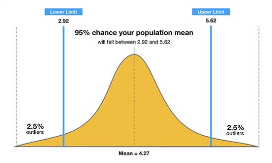

1. Calcule o Intervalo de Confiança de “idade” da planilha “Alunos”, da seguinte forma:
- Calcule a média da população de valores;
- Calcule o tamanho da população de valores (quantos valores existem)
- Calcule o desvio padrão da população de valores
- Calcule o erro padrão, dividindo o desvio padrão pela raiz quadrada do tamanho da população;
- Defina o intervalo de confiança e nomeie como “alpha”. Ex. Alpha de 90% = 0.10; alpha de 95% = 0.05, etc;
- Calcule o grau de liberdade. Grau de liberdade é o tamanho da população -1. Nomeie como “degrees_of_freedom”;
- Calcule o t-score relacionado ao CI. Veja “Dicas” para calcular t-score;
- Calcule a margem de erro, multiplicando t-score por erro padrão;
- Calcule a margem superior e inferior do intervalo de confiança. Margem superior = media + margem de erro; Margem inferior = média – margem de erro

Dicas! - Realize as etapas na sequencia apresentada. Nomeie cada objeto, pois eles serão utilizados nas etapas seguintes.

- Você irá usar uma série de função que aprendemos. São elas: mean, sd, sqrt, length.
- Você também irá usar operações matemáticas: São elas, soma (+); subtração (-), multiplicação, (*) e divisão (/)
- T-score = qt(p=alpha/2, df=degrees_of_freedom,lower.tail=F)

### Outras funções úteis

Função “sub()”. A função “sub()” permite substituir o valor de um vetor, ou de um vetor dentro de um dataframe, ou lista

```r
# Vetores

letras <- letters[1:10]
sub(pattern = "b", replacement = "z", x = letras)
```

```
##  [1] "a" "z" "c" "d" "e" "f" "g" "h" "i" "j"
```

```r
sexo <- alunos$sexo
sexo
```

```
## [1] "Masculino" "F"         "M"         "F"
```

```r
sexo <- sub(pattern = "Masculino", replacement = "M", x = sexo)
sexo
```

```
## [1] "M" "F" "M" "F"
```

```r
sexo <- sub(pattern = "Feminino", replacement = "F", x = sexo)
sexo
```

```
## [1] "M" "F" "M" "F"
```

```r
letras_2 <- c(letras, letras)

sub(pattern = "c", replacement = "z", x = letras_2)
```

```
##  [1] "a" "b" "z" "d" "e" "f" "g" "h" "i" "j" "a" "b" "z" "d" "e" "f" "g" "h" "i"
## [20] "j"
```

```r
letras_2
```

```
##  [1] "a" "b" "c" "d" "e" "f" "g" "h" "i" "j" "a" "b" "c" "d" "e" "f" "g" "h" "i"
## [20] "j"
```

??? Porque a função não funcionou? Lembre-se que você precisa nomear o objeto sendo criado com a substituição

```r
letras_2 <- sub(pattern = "c", replacement = "z", x = letras_2)

letras_2
```

```
##  [1] "a" "b" "z" "d" "e" "f" "g" "h" "i" "j" "a" "b" "z" "d" "e" "f" "g" "h" "i"
## [20] "j"
```

Dataframe

```r
alunos
```

```
## # A tibble: 4 × 10
##   nome              idade sexo  altura  peso trans…¹ semes…²    pe   mao inici…³
##   <chr>             <dbl> <chr>  <dbl> <dbl> <chr>     <dbl> <dbl> <dbl> <lgl>
## 1 Daniel Maurenza …    39 Masc…   1.7     72 Publico       5    40    22 TRUE
## 2 Maria                20 F       1.58    49 Publico       4    35    20 FALSE
## 3 Joao                 40 M       1.8     90 Privado       5    37    20 FALSE
## 4 Joana                25 F       1.75    65 Publico       1    33    21 TRUE
## # … with abbreviated variable names ¹transporte, ²semestre, ³iniciante
```

```r
sub(pattern = "Masculino", replacement = "M", alunos$sexo)
```

```
## [1] "M" "F" "M" "F"
```

```r
alunos
```

```
## # A tibble: 4 × 10
##   nome              idade sexo  altura  peso trans…¹ semes…²    pe   mao inici…³
##   <chr>             <dbl> <chr>  <dbl> <dbl> <chr>     <dbl> <dbl> <dbl> <lgl>
## 1 Daniel Maurenza …    39 Masc…   1.7     72 Publico       5    40    22 TRUE
## 2 Maria                20 F       1.58    49 Publico       4    35    20 FALSE
## 3 Joao                 40 M       1.8     90 Privado       5    37    20 FALSE
## 4 Joana                25 F       1.75    65 Publico       1    33    21 TRUE
## # … with abbreviated variable names ¹transporte, ²semestre, ³iniciante
```

Similarmente aos vetores, é necessário nomear o objeto sendo criado com a substituição

```r
#
alunos$sexo <- sub(pattern = "Masculino", replacement = "M", alunos$sexo)
alunos
```

```
## # A tibble: 4 × 10
##   nome              idade sexo  altura  peso trans…¹ semes…²    pe   mao inici…³
##   <chr>             <dbl> <chr>  <dbl> <dbl> <chr>     <dbl> <dbl> <dbl> <lgl>
## 1 Daniel Maurenza …    39 M       1.7     72 Publico       5    40    22 TRUE
## 2 Maria                20 F       1.58    49 Publico       4    35    20 FALSE
## 3 Joao                 40 M       1.8     90 Privado       5    37    20 FALSE
## 4 Joana                25 F       1.75    65 Publico       1    33    21 TRUE
## # … with abbreviated variable names ¹transporte, ²semestre, ³iniciante
```

```r
alunos$sexo <- sub(pattern = "Feminino", replacement = "F", alunos$sexo)
alunos
```

```
## # A tibble: 4 × 10
##   nome              idade sexo  altura  peso trans…¹ semes…²    pe   mao inici…³
##   <chr>             <dbl> <chr>  <dbl> <dbl> <chr>     <dbl> <dbl> <dbl> <lgl>
## 1 Daniel Maurenza …    39 M       1.7     72 Publico       5    40    22 TRUE
## 2 Maria                20 F       1.58    49 Publico       4    35    20 FALSE
## 3 Joao                 40 M       1.8     90 Privado       5    37    20 FALSE
## 4 Joana                25 F       1.75    65 Publico       1    33    21 TRUE
## # … with abbreviated variable names ¹transporte, ²semestre, ³iniciante
```

Função “round()” Usamos a função “round” para arredondar valores numéricos. Para exemplificar, vamos criar um vetor com 100 valores com uma distribuição normal, sendo a média = 3000 e o desvio padrão = 2000

```r
vetor <- rnorm(n = 100,mean = 3000, sd = 2000)
vetor
```

```
##   [1]  166.64578 3847.49704 3042.14151 2540.30355 1716.38746 3970.59340
##   [7] 2683.78620 5950.97078 3623.51828 6300.71264 3303.69758 2283.20115
##  [13] 3450.47848 1917.36946 4369.93303 2125.57783  552.22970 1926.92182
##  [19] 5344.78532 1765.63575 4165.61348 5316.83435 1698.63856 3912.68849
##  [25] 3992.27945 3565.10017 2430.57909 3070.09991 6611.84326 5531.02420
##  [31] 1797.84124 1118.43496 3071.80571 2525.45324 4947.54578 2607.44058
##  [37] 3456.62315   67.39712 2247.56072 4830.06463 -110.65179 3163.08126
##  [43] 3202.90112 4220.83594 6258.11382 3832.49883 2553.89709 4697.29484
##  [49] 4144.83333 3775.11804 -928.31535 4083.31181 3750.22560 5273.21783
##  [55] 4921.21736 1561.25589  254.39605 1897.01236  898.52255 4122.42467
##  [61] 2943.79857 -817.05749 -515.29638 1316.62160 1392.03692 2730.30151
##  [67] 3691.50401 5959.97277 4610.83643 -473.72552 3974.89161 6920.67305
##  [73] 5518.75911 4856.64495  782.12853 4256.14320 3372.41410 2701.67555
##  [79] 5722.81383 3334.86036 2666.97052  751.97453 5634.99226 -357.42670
##  [85] 2997.44421 2572.98726 1771.28839 2699.06404 1874.40479 1056.80633
##  [91] 2543.21707 5257.02988 5986.71978 5527.52187 1100.72249 2968.68328
##  [97] 2185.62923 4249.23720 -660.93337 1385.43062
```

```r
round(x = vetor)
```

```
##   [1]  167 3847 3042 2540 1716 3971 2684 5951 3624 6301 3304 2283 3450 1917 4370
##  [16] 2126  552 1927 5345 1766 4166 5317 1699 3913 3992 3565 2431 3070 6612 5531
##  [31] 1798 1118 3072 2525 4948 2607 3457   67 2248 4830 -111 3163 3203 4221 6258
##  [46] 3832 2554 4697 4145 3775 -928 4083 3750 5273 4921 1561  254 1897  899 4122
##  [61] 2944 -817 -515 1317 1392 2730 3692 5960 4611 -474 3975 6921 5519 4857  782
##  [76] 4256 3372 2702 5723 3335 2667  752 5635 -357 2997 2573 1771 2699 1874 1057
##  [91] 2543 5257 5987 5528 1101 2969 2186 4249 -661 1385
```

```r
round(x = vetor, digits = 2)
```

```
##   [1]  166.65 3847.50 3042.14 2540.30 1716.39 3970.59 2683.79 5950.97 3623.52
##  [10] 6300.71 3303.70 2283.20 3450.48 1917.37 4369.93 2125.58  552.23 1926.92
##  [19] 5344.79 1765.64 4165.61 5316.83 1698.64 3912.69 3992.28 3565.10 2430.58
##  [28] 3070.10 6611.84 5531.02 1797.84 1118.43 3071.81 2525.45 4947.55 2607.44
##  [37] 3456.62   67.40 2247.56 4830.06 -110.65 3163.08 3202.90 4220.84 6258.11
##  [46] 3832.50 2553.90 4697.29 4144.83 3775.12 -928.32 4083.31 3750.23 5273.22
##  [55] 4921.22 1561.26  254.40 1897.01  898.52 4122.42 2943.80 -817.06 -515.30
##  [64] 1316.62 1392.04 2730.30 3691.50 5959.97 4610.84 -473.73 3974.89 6920.67
##  [73] 5518.76 4856.64  782.13 4256.14 3372.41 2701.68 5722.81 3334.86 2666.97
##  [82]  751.97 5634.99 -357.43 2997.44 2572.99 1771.29 2699.06 1874.40 1056.81
##  [91] 2543.22 5257.03 5986.72 5527.52 1100.72 2968.68 2185.63 4249.24 -660.93
## [100] 1385.43
```